## The Effect of Weather on People and Property

#### A study on weather in the USA from 1950 to 2011

##### By: Fred Stakem

##### Date: 8.20.14

### Synopsis

Every year extreme weather in America caused a significant amount of casualties and damage to property. The purpose of this analysis was to calculate the amount of casualties and damage for different types of weather events. The data for this analysis was obtained from the NOAA storm database showing severe weather events from 1950 to November 2011. The results show tornados as the leading cause of casualties and floods as the leading cause of damage. It it recommended that the majority of money spent monitoring weather conditions should be allocated to tornados, floods, and hurricanes because they have the greatest effect on property and people.

### Data Processing

The first part of the data processing consisted of a script to download and extract the compressed data file from the following link.

Data url: https://d396qusza40orc.cloudfront.net/repdata%2Fdata%2FStormData.csv.bz2

For sake of simplicity this code was ommited. Once the data was downloaded and extracted the file was read into memory.

```r
data_file <- './raw_data/storm.csv'
raw_data <- read.table(data_file, fill=TRUE, sep=',', header=TRUE)
```

Once the data was in R a decent amount of time was spent researching the EVTYPE column that contained the weather events. A first glance at the weather events made them seem to be well formed. After working with the data a bit it was realized that many different labels were given to the same weather events. The most important events for this data analysis were capture in a map that also has the regex used to search for the event. This can be seen below. This list was constantly modified as the analysis progressed so that the most import events were included.

```r
event_str <- new.env(hash=T, parent=emptyenv())
event_str$tornado <- 'tornado'
event_str$heat <- 'heat'
event_str$drought <- '^drought$'
event_str$wind <- 'wind'
event_str$flood <- 'flood'
event_str$lightning <- 'lightning'
event_str$ice <- 'ice'
event_str$current <- 'current|surf'
event_str$hail <- 'hail'
event_str$hurricane <- 'hurricane|tropical'
event_str$snow <- 'blizzard|snow|winter'
event_str$fog <- 'fog'
event_str$fire <- 'fire'
event_str$dust_storm <- 'dust storm'
event_str$avalanche <- 'avalanche'
event_str$cold <- 'cold'
event_str$rain <- 'rain'
event_str$surge <- 'surge'
event_str$frost <- 'frost'
```

#### Question 1

*Across the United States, which types of events (as indicated in the EVTYPE variable) are most harmful with respect to population health?*

First the injuries were groupped according to the event type and stored in a data frame.

```r
total_injuries <- aggregate(raw_data$INJURIES ~ raw_data$EVTYPE, raw_data, sum)
colnames(total_injuries)[1] <- 'event'
colnames(total_injuries)[2] <- 'injury'
```

Next the fatalities were groupped according to the event type and stored in a data frame.

```r
total_fatalities <- aggregate(raw_data$FATALITIES ~ raw_data$EVTYPE, raw_data, sum)
colnames(total_fatalities)[1] <- 'event'
colnames(total_fatalities)[2] <- 'fatality'
```

A new data frame was created that held the total casualties for each event.

```r
total_human_loss <- data.frame(event=total_fatalities$event)
total_human_loss$human.loss <- total_fatalities$fatality + total_injuries$injury
```

Once the total casualties was found the data frame was sorted according to the total casualties. This step was important to make sure all of the greatest occuring casualties were in the map mentioned above. If the event was not in the map then the event would no be included in the final analysis. A great deal of time was spent searching the data for duplicate labels for the same event.

```r
sorted_human_loss <- total_human_loss[order(total_human_loss$human.loss, decreasing=TRUE),]
```

After the top occuring events for casualties was referenced and included in the map, the data was filtered on these events. Similar events were aggregated together. For example the event *heat* had some of the following labels: *EXCESSIVE HEAT*, *EXTREME HEAT*, *HEAT*, *HEAT WAVE*. The step finished the data wrangling of the casuality information and all that was needed for the final analysis was to plot the data.

```r
event <- character(0)
loss <- numeric(0)
i <- 0
for(e_str in ls(event_str))
{
    event[i] <- e_str
    loss[i] <- sum( sorted_human_loss[grep(event_str[[e_str]], sorted_human_loss$event, ignore.case=TRUE), ]$human.loss )
    i <- i + 1
}

filtered_human_loss <- data.frame(event=event, loss=loss)
```

#### Question 2

*Across the United States, which types of events have the greatest economic consequences?*

Answering this question was a little more complex than the previous question due to the way the data was stored. The data was split between property damage and crop damage with each having an additional column for the exponent of the value. According to the NOAA documentation the exponent portion of the value should only have a value of ‘K’, ‘M’, or ‘B’ or nothing at all. The following function was devised to calculate the total damage based upon the base value and its exponent. Exponents that did not follow the NOAA standard were ignored.

```r
calculate_damage <- function(damage)
{
    multiplier <- 1
    value <- as.numeric(damage[1])
    exponent <- damage[2]

    if(exponent == 'K')
    {
        multiplier <- 1000
    } else if(exponent == 'M')
    {
        multiplier <- 1000000
    } else if(exponent == 'B')
    {
        multiplier <- 1000000000
    }

    value * multiplier
}
```

First the property damage was calculated for each observation based upon the base value and its exponent.

```r
raw_property_damage <- raw_data[, c('PROPDMG', 'PROPDMGEXP')]
na_rows <- which(is.na(raw_property_damage$PROPDMGEXP) == TRUE)
raw_property_damage$PROPDMGEXP[na_rows] <- '-'
calculated_property_damage <- apply(raw_property_damage, 1, calculate_damage)

property_damage <- data.frame(event=raw_data$EVTYPE)
property_damage$dmg.value <- calculated_property_damage
colnames(property_damage)[2] <- 'property.damage'
```

Next the crop damage was calculated for each observation based upon the base value and its exponent.

```r
raw_crop_damage <- raw_data[, c('CROPDMG', 'CROPDMGEXP')]
na_rows <- which(is.na(raw_crop_damage$CROPDMGEXP) == TRUE)
raw_crop_damage$CROPDMGEXP[na_rows] <- '-'
calculated_crop_damage <- apply(raw_crop_damage, 1, calculate_damage)

crop_damage <- data.frame(event=raw_data$EVTYPE)
crop_damage$dmg.value <- calculated_crop_damage
colnames(crop_damage)[2] <- 'crop.damage'
```

Once both the property damage and the crop damage were calculated the total damage was calculated for each observation.

```r
economic_loss <- data.frame(event=property_damage$event)
economic_loss$dollars <- property_damage$property.damage + crop_damage$crop.damage
```

Finally the total damage was found for each event type.

```r
total_economic_loss <- aggregate(economic_loss$dollars ~ economic_loss$event, economic_loss, sum)
colnames(total_economic_loss)[1] <- 'event'
colnames(total_economic_loss)[2] <- 'dollars'
```

As in the analysis for the first question the data was sorted to make sure the top contributors were used in the map for the final analysis.

```r
sorted_economic_loss <- total_economic_loss[order(total_economic_loss$dollars, decreasing=TRUE),]
```

After the top occuring events for total damage was referenced and included in the map, the data was filtered on these events. Similar events were aggregated together.

```r
event <- character(0)
loss <- numeric(0)
i <- 0
for(e_str in ls(event_str))
{
    event[i] <- e_str
    loss[i] <- sum( sorted_economic_loss[grep(event_str[[e_str]], sorted_economic_loss$event, ignore.case=TRUE), ]$dollars )
    i <- i + 1
}

filtered_economic_loss <- data.frame(event=event, loss=loss)
filtered_economic_loss <- filtered_economic_loss[order(filtered_economic_loss$loss, decreasing=TRUE),]
final_economic_loss <- data.frame(event=filtered_economic_loss$event, loss=filtered_economic_loss$loss)
```

### Results

#### Question 1

*Across the United States, which types of events (as indicated in the EVTYPE variable) are most harmful with respect to population health?*

For the analysis of the casualty data the filtered data was first sorted.

```r
filtered_human_loss <- filtered_human_loss[order(filtered_human_loss$loss, decreasing=TRUE),]
final_human_loss <- data.frame(event=filtered_human_loss$event, loss=filtered_human_loss$loss)
```

Finally the top five events were plotted in a bar graph. As can be seen from the bar graph tornados are by far the leading cause of weather casualties.

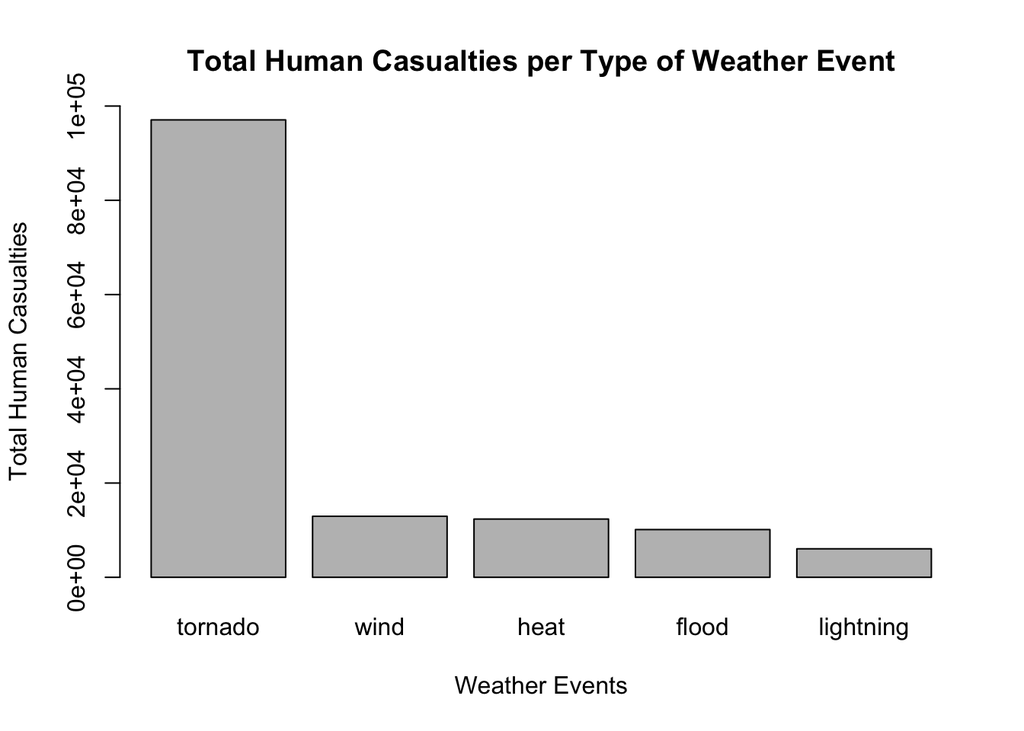

```r
plotting_data <- final_human_loss$loss[1:5]
plotting_labels <- final_human_loss$event[1:5]
barplot(plotting_data, names.arg=plotting_labels, xlab="Weather Events", ylab="Total Human Casualties", main="Total Human Casualties per Type of Weather Event", yaxp=c(0,100000,5))
```

#### Question 2

*Across the United States, which types of events have the greatest economic consequences?*

For the analysis of the damage data the filtered data was first sorted.

```r
filtered_economic_loss <- filtered_economic_loss[order(filtered_economic_loss$loss, decreasing=TRUE),]
final_economic_loss <- data.frame(event=filtered_economic_loss$event, loss=filtered_economic_loss$loss)
```

Finally the top five events were plotted in a bar graph. The plot shows floods as the causing the most property damage, but hurricanes also cause a significant amount of damage.

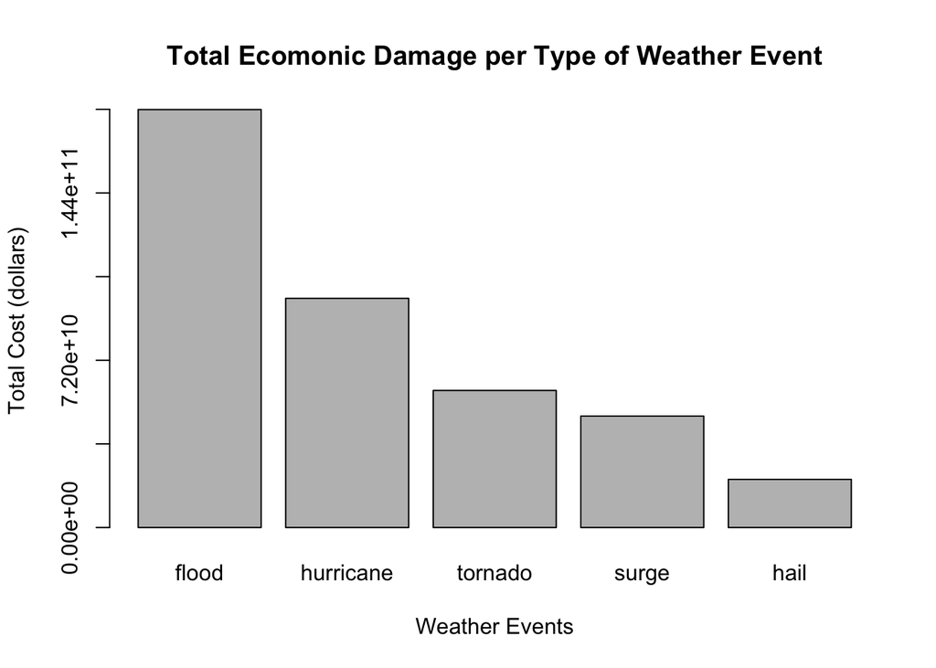

```r
plotting_data <- final_economic_loss$loss[1:5]
plotting_labels <- final_economic_loss$event[1:5]
barplot(plotting_data, names.arg=plotting_labels, xlab="Weather Events", ylab="Total Cost (dollars)", main="Total Ecomonic Damage per Type of Weather Event", yaxp=c(0,180000000000,5))
```